# Lab04

## Reading in the data

```r
met_all <- read.csv("~/Downloads/met_all.gz")
```

## Preparing the data

```r
library(dplyr)
library(tidyr)
met2 <- filter(met_all, temp >= -17, !is.na(temp), !is.na(rh), !is.na(wind.sp), !is.na(vis.dist), !is.na(dew.point),!is.na(lat), !is.na(lon), !is.na(elev))


met2$date <- as.Date(paste(met2$year, met2$month, met2$day, sep = "-"))


met2 <- met2[order(met2$date, decreasing=FALSE),]


first7 <- met2[met2$day<=7,]


means <- first7 %>%
  group_by(USAFID) %>%
  summarise(
    tempm      = mean(temp, na.rm = TRUE),
    rhm        = mean(rh, na.rm = TRUE),
    wind.spm   = mean(wind.sp, na.rm = TRUE),
    vis.distm  = mean(vis.dist, na.rm = TRUE),
    dew.pointm = mean(dew.point, na.rm = TRUE),
    latm       = mean(lat, na.rm = TRUE),
    lonm       = mean(lon, na.rm = TRUE),
    elevm      = mean(elev, na.rm = TRUE)
  )


means_combined <- means %>%
  left_join(first7, by = "USAFID")


means_combined$region <- ifelse(!is.na(means_combined$lat) & !is.na(means_combined$lon),
                          ifelse(means_combined$lat >= 39.71 & means_combined$lon < -98.00, "NW",
                          ifelse(means_combined$lat < 39.71  & means_combined$lon < -98.00, "SW",
                          ifelse(means_combined$lat >= 39.71 & means_combined$lon >= -98.00, "NE", "SE"))),
                          NA)

means_combined$elev_cat <- ifelse(means_combined$elev > 252, "High", "Low")
```

## Examine the relative humidity and dew point by region (GeomViolin)

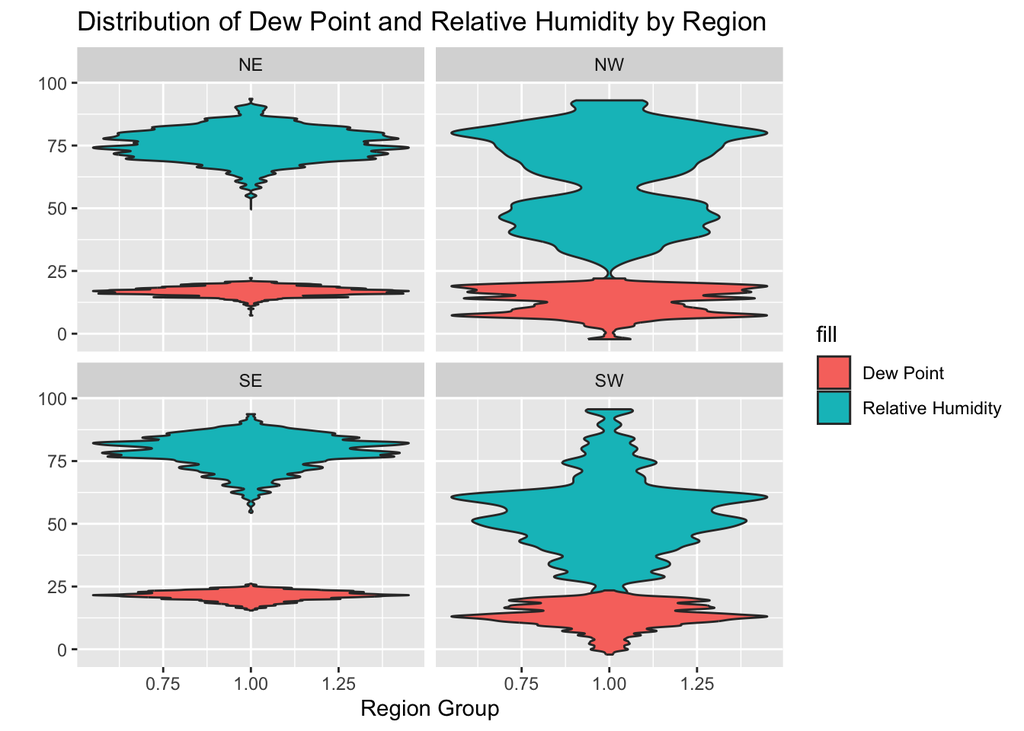

```r
library(ggplot2)

plot_data <- means_combined[!is.na(means_combined$region) &
                            !is.na(means_combined$rhm) &
                            !is.na(means_combined$dew.pointm), ]
ggplot(data = plot_data) +
  geom_violin(aes(x = 1, y = rhm, fill = "Relative Humidity"), na.rm = TRUE) +
  geom_violin(aes(x = 1, y = dew.pointm, fill = "Dew Point"), na.rm = TRUE) +
  facet_wrap(~ region,nrow=2, ncol=2) +  labs(
    title = "Distribution of Dew Point and Relative Humidity by Region",
    x = "Region Group",
    y = "")
```

Relative Humidity spans a high range between 25% and 100% across western regions. In the eastern regions, Relative Humidity spans across a tighter range of 50% to 100%.Dew Point is clustered at much lower ranges. In Easter regions, dew points span across an extremely tight region of about 12.5% to 25%, while in western regions, dew points are mostly concentrated between 0% to 25%.

## Examine the association between dew point and relative humidity by region (Geom Point)

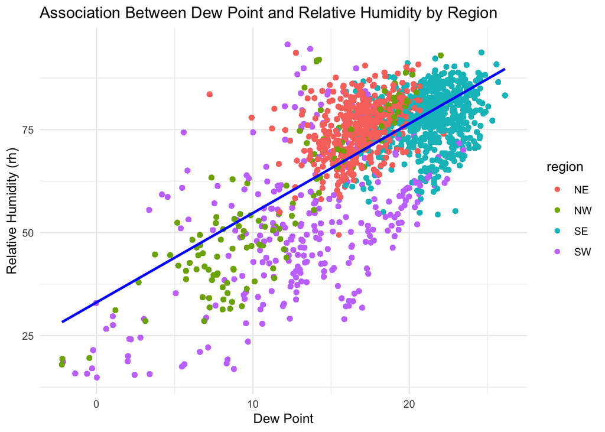

```r
ggplot(data = means_combined[!is.na(means_combined$region), ],
  mapping = aes(x = dew.pointm, y = rhm, color = region)
) +
  geom_point(na.rm = TRUE) +
  geom_smooth(method = "lm", se = FALSE, col="blue") +
  labs(
    title = "Association Between Dew Point and Relative Humidity by Region",
    x = "Dew Point",
    y = "Relative Humidity (rh)"
  ) +
  theme_minimal()
```

Based on this plot, Dew Point is highly and positively correlated with Relative Humidity. Southwest and Northwest regions have data points more spread out while regions in Northeast and Southeast are clustered at higher ranges of humidity and dew point.

## Create barplots of the weather stations by elevation category colored by region

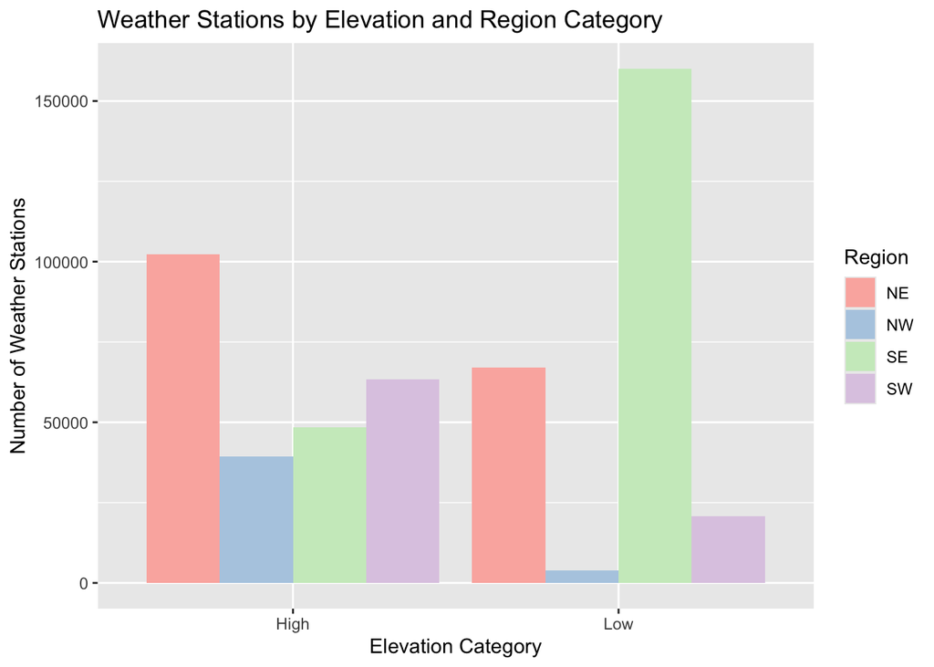

```r
means_combined[!is.na(means_combined$elev_cat), ] %>%
  ggplot() +
  geom_bar(mapping = aes(x = elev_cat, fill = region), position = "dodge", na.rm = TRUE) + scale_fill_brewer (palette = "Pastel1") + labs(title = "Weather Stations by Elevation and Region Category", x = "Elevation Category", y = "Number of Weather Stations", fill = "Region")
```

## Examine mean dew point and wind speed by region with standard deviation error bars

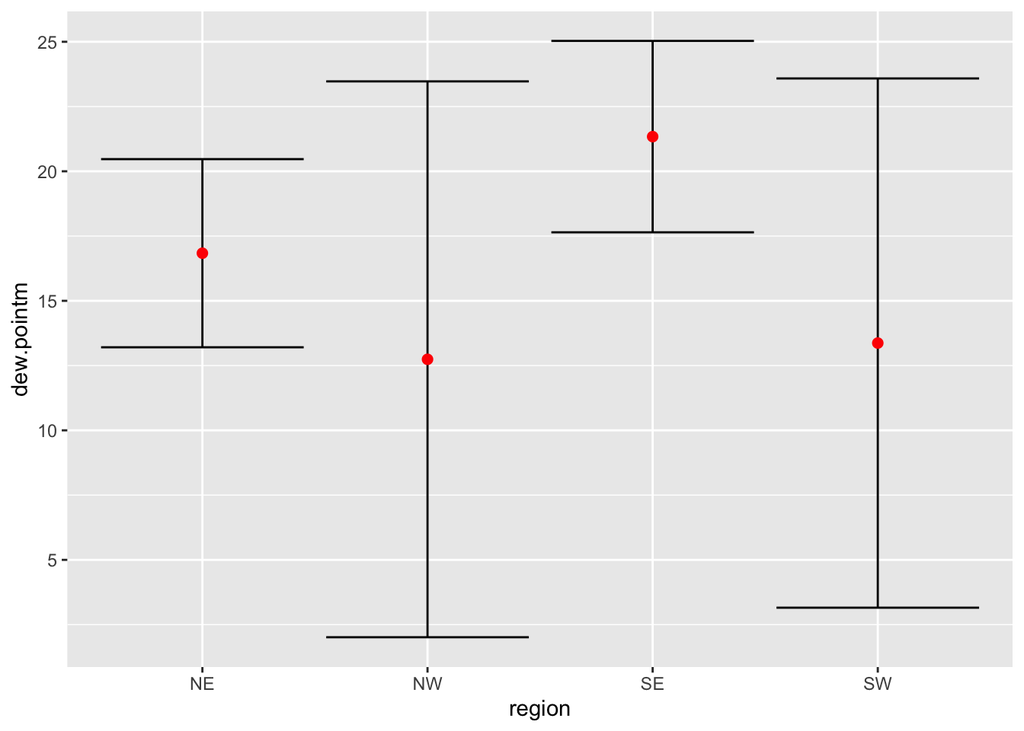

```r
dewpt <- means_combined[!is.na(means_combined$dew.pointm),] %>%
  ggplot(mapping = aes(x = region, y = dew.pointm)) +
    stat_summary(fun.data = "mean_sdl", geom = "errorbar") +
    stat_summary(fun = "mean", geom = "point", size = 2, color = "red")
dewpt
```

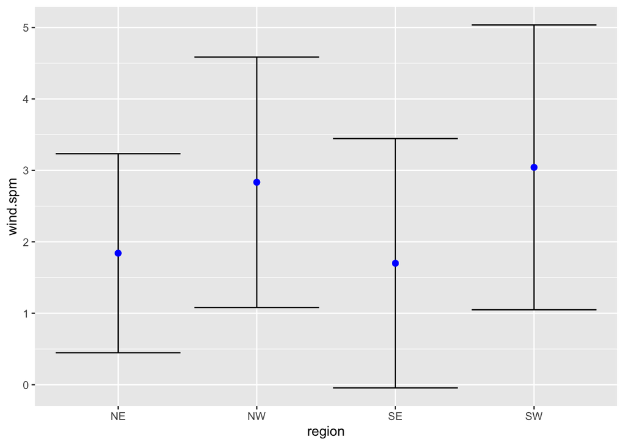

```r
windsp <- means_combined[!is.na(means_combined$wind.spm),] %>%
  ggplot(mapping = aes(x = region, y = wind.spm)) +
    stat_summary(fun.data = "mean_sdl", geom = "errorbar") +
    stat_summary(fun = "mean", geom = "point", size = 2, color = "blue")
windsp
```

Dew point means are higher and SD is lower in the Eastern regions than the overall Western regions. This suggests that there is less variability in the eastern regions. The Southeast has the highest mean dew point, and Northeast follows right after. Northwest and Southwest have lower mean dew points and higher SD, suggesting that there is high variability in these regions.

Wind speed means are higher in the Western regions compared to Eastern regions. The Southwest has the highest mean wind speed, and Northwest follows right. All regions have relatively same level of high error bars/SD, suggesting high variability in all regions.

## Map showing the spatial trend in relative humidity in the US

```r
library(leaflet)
library(dplyr)
means_combined <- means_combined %>% filter(!is.na(rhm), !is.na(latm), !is.na(lonm))

rh.pal <- colorNumeric(c('darkgreen','goldenrod','brown'), domain=means_combined$rhm)

rh_map <- leaflet(means_combined) %>%
  addTiles() %>%
  addCircles(lat = ~latm, lng = ~lonm, label = ~paste0(round(rhm,2), 'C'), color = ~ rh.pal(rhm), opacity = 1, fillOpacity = 1, radius = 500) %>%
  addLegend('bottomleft', pal=rh.pal, values=means_combined$rhm, title = 'Relative Humidity, %', opacity = 1) %>%
  addMarkers(data = means_combined %>% filter(rank(-rhm) <= 10),lat = ~latm,
    lng = ~lonm)

rh_map
```

[interactive chart not shown]

## ggforce extension

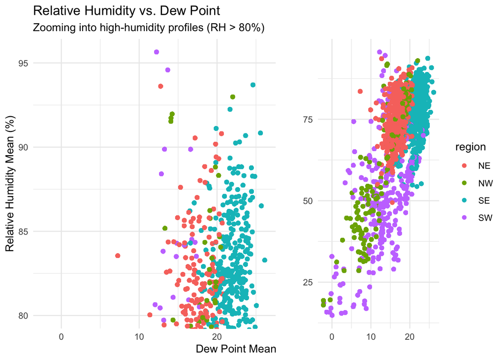

```r
library(ggforce)
means_combined <- means_combined %>% filter(!is.na(dew.pointm), !is.na(rhm), !is.na(region))

ggplot(means_combined,aes(x = dew.pointm, y = rhm, color = region)) +
  geom_point() +
  labs(
    title = "Relative Humidity vs. Dew Point",
    subtitle = "Zooming into high-humidity profiles (RH > 80%)",
    x = "Dew Point Mean",
    y = "Relative Humidity Mean (%)"
  ) +
  theme_minimal() +
   facet_zoom(y = rhm > 80)
```